# A4: Incarceration

Leila Peitsch

### Introduction

In the US, black people have been found to be overrepresented in jails and prisons despite only making up [12% of local populations](https://www.pewtrusts.org/en/research-and-analysis/issue-briefs/2023/05/racial-disparities-persist-in-many-us-jails). A everlasting trend within American prisons is young black men making up a majority of all incarcerations. Following the BLM movement resurgence in 2020 as a reaction to the murder of George Floyd committed by the police - more awareness has been brought to the unjust treatment of black individuals by the police and overall justice system.  
In this report, I will be looking at data covering the US jail populations of different races, specifically that of black and white populations, and how race, gender, age, and location can affect the demographics within the jail.

### Summary Information

When observing the demographics with those incarcerating in local jails, it is important to keep in mind how the individuals’ race, age, and location can affect how these statistics change between state lines. For example, the state with the highest jail population within urban neighborhoods (defined as one of the core counties of a metropolitan area with about a million people) was **California**. However, the state with the highest jail population within rural neighborhoods (defined as non-metro areas with less than 10,000 people) was **Texas**.

Based on state demographics, Texas has the highest black population in the US, despite the group only making up [12% of the total population](https://blackdemographics.com/population/black-state-population/). Looking at the jail populations across races in Texas, specifically that of white and black populations, the highest white jail population was **5565** whereas the highest black jail population was **5688**. While this difference isn’t extreme, based on the demographics, one would expect white jail populations to be much higher than that of any other minority groups.

This unjust treatment of black populations in regards to the US incarceration system is also seen in the ratio between black and white jail populations. In 2015, the highest reported ratio between black and white populations in jail was **104**, that being for every white individual in jail there were **104** black individuals in jail - this ratio being reported from **Mississippi**.

### The Dataset

The data was collected by the [Vera Institute](https://github.com/vera-institute/incarceration-trends). The data is sourced from the Bureau of Justice Statistics (BJS), specifically using data from the Census of Jails (COJ) and Annual Survey of Jails (ASJ). This data was curated in order to observe patterns within incarcerations across the country, including on a county-level. This way the data could provide information on whether someone’s location, gender, race, age, and other personal factors outside of the reason they were arrested could affect if they were arrested and/or charged.

In the dataset I used that covers jail populations from 1970 - 2018 across the US, there are 153,811 observations and 28 features - that being the subsets of different demographics (i.e. black jail population, female jail population). When working with this data, it is important to keep in mind the historical biases that often arise when observing trends that factor in one’s race. Unfortunately, people within the BIPOC community have been unfairly targeted by the police across the US, often due to misleading and unfounded stereotypes that have no merit and only exist due to outdated mindsets. Within systems that punish those who have been believed to break the law, whether on a federal or local level, it has been well-documented that these systems are corrupt in a number of ways - which will hopefully be exposed in the data.

The limitations within this dataset is firstly the size of it. While lots of data is helpful when observing trends, having too many columns and observations can make identifying and graphing patterns difficult and time-consuming to load. Also, while there is a lot of data in broader categories (i.e. total jail pop.), the features that focus on particular groups, such as race or gender, hold many NA values. The problem with NA values is the easiest way to work with them is to omit them from the values you consider when analyzing, but this doesn’t reflect the actual value of the NA as there could have been individuals in this category that were not counted. This is why it is important to observe the implications of trends in data, while not accepting them as a solidified fact.

### Trends Over Time

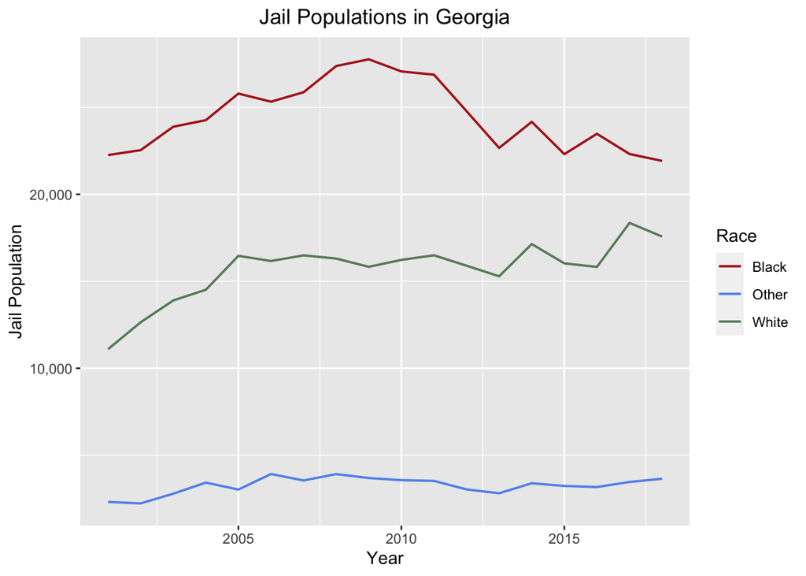

This graph observes **total jail populations** in **Georgia** between 2000 - 2018. The populations are separated into three groups based on the reported race of the individual: Black population, White population, and Latinx/AAPI/ Indigenous/Other race population.  
I chose to focus within Georgia state as they have a more even split between their white and black populations, even though their black population still falls well into the minority (36% of local population).

Despite this, as observed in the chart, the black jail population is still much more sizeable than the white jail population or the population of all other minority groups. While there seems to be a *decrease* in black jail populations beginning in 2010, there is still a **big difference** between the arrests and jail holding of black and white individuals.

This chart supports the claim that the US justice system unfairly targets black people over other racial groups.

### Variable Comparison

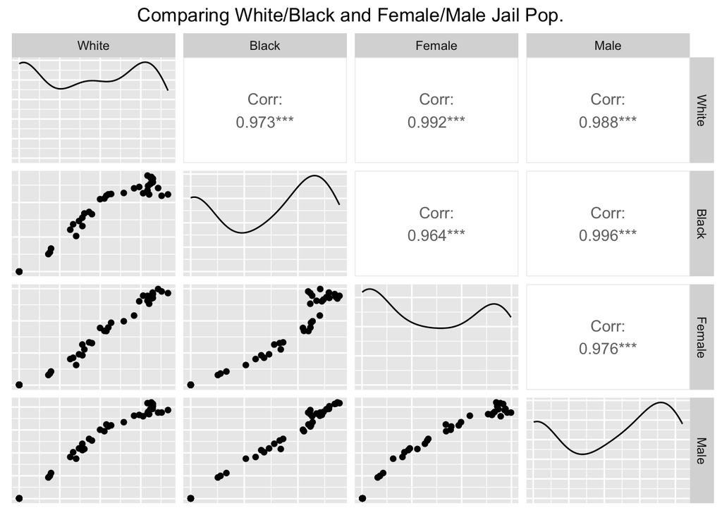

This chart compares various features: those being black jail populations, white jail populations, female jail populations, and male jail populations. This counts specifically cover **Georgia** state across all years and counties.

The scatterplots show that the strongest correlation out of all the different comparisons is between that of black and male jail populations. While this doesn’t prove a relationship between these two factors, it can be inferred that black men have the highest jail populations. This observation has also been observed by the [*National Institute of Justice*](https://nij.ojp.gov/media/image/19511).

### Map

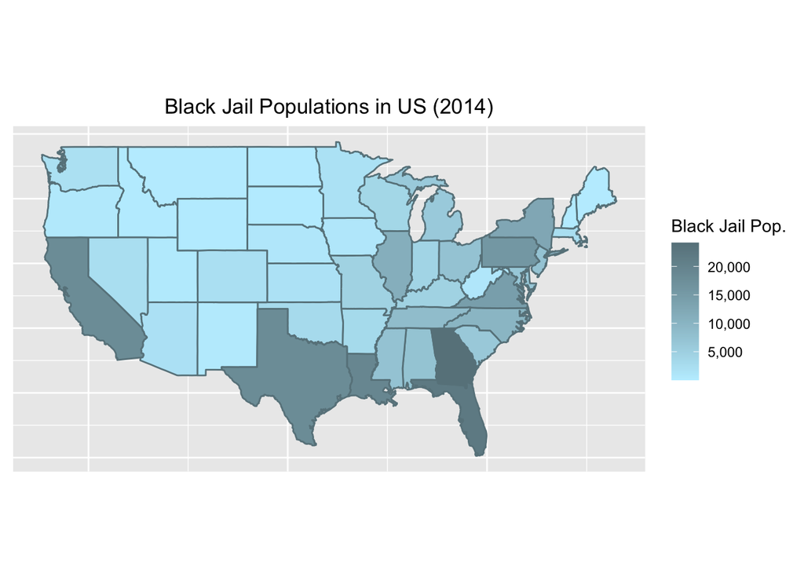

This map shows the **black jail populations** in each state across the US in 2014.  
It can be observed that in more dense states, the populations are larger, such as in Texas and California. Though it could also be noted that black jail populations seem to be much larger in states that have deeper histories with racism.

Coincidentally, most of the states with higher black jail populations also have the largest number of reported [*sundown towns*](https://justice.tougaloo.edu/map/) - signifying these places have large white populations with discriminatory and harmful views.